# Statistical inference with the GSS data

## Setup

### Load packages

```r
library(ggplot2)
library(dplyr)
library(statsr)
```

### Load data

```r
load("../DataSets/gss.Rdata")
```

## Part 1: Data

The general social survey (GSS) has been around for more than four decades and it’s a door-to-door survey asked to people in the United States. Every year researches visit the homes of americans and ask them a long list of questions about their history behavior and opinions on a number of topics of interest to social scientist. There are generally a few thousand people that are surveyed every year but researches would like to make general statements about the opinions and social trends of the entire United States, this process of inference from the sample to the population is possible because the researches are careful to select the respondents in such a way that their sample is representative of the population of all Americans, the result is a data set where each sampled respondent is one row and each columns is their response to a single question.

The gss data set contains 57061 rows (people) and 114 columns (variables representing each question of the survey). However, many variables have missing values (NAs).

For more detailed information about this data set and methodology, see the official site: http://www.gss.norc.org.

```r
dim(gss)
```

```
## [1] 57061   114
```

## Part 2: Research question

Considering the most current year of the data set (2012), is there a difference between catholic and protestant in the vehement condemnation of homosexuals?

Historically Protestants have fewer restrictions than Catholics, so in theory they should be more open to homosexuality, but there is apparently an impression in the community that they reject homosexuality more. So it would be interesting to know how people think of these two main beliefs, considering that both have tha same base, the Bible.

## Part 3: Exploratory data analysis

```r
summary(gss$homosex)
```

```
##     Always Wrong Almst Always Wrg  Sometimes Wrong Not Wrong At All
##            21601             1581             2243             7282
##            Other             NA's
##               82            24272
```

First, let’s analyze the possible responses about the sexual relations between two adults of the same sex in all religions

```r
table(gss$relig,gss$homosex)
```

```
##
##                           Always Wrong Almst Always Wrg Sometimes Wrong
##   Protestant                     14801              855            1073
##   Catholic                        4853              484             650
##   Jewish                           173               28              77
##   None                            1112              161             353
##   Other                            296               27              52
##   Buddhism                          12                2               3
##   Hinduism                          12                0               5
##   Other Eastern                      6                0               1
##   Moslem/Islam                      39                2               1
##   Orthodox-Christian                16                3               2
##   Christian                        183               11              16
##   Native American                    5                0               0
##   Inter-Nondenominational           37                3               7
##
##                           Not Wrong At All Other
##   Protestant                          2900    38
##   Catholic                            1893    23
##   Jewish                               338     8
##   None                                1710    11
##   Other                                209     2
##   Buddhism                              49     0
##   Hinduism                              13     0
##   Other Eastern                          8     0
##   Moslem/Islam                          10     0
##   Orthodox-Christian                    19     0
##   Christian                             89     0
##   Native American                        5     0
##   Inter-Nondenominational               19     0
```

We will select only people who strongly disagree and remove all null values and filter by the year 2012

```r
GSSData <- gss %>% filter(!(is.na(relig)) & !(is.na(homosex)) & year=='2012')

GSSData %>%
  group_by(relig) %>%
  summarise(percentage = sum(homosex=='Always Wrong')/n())
```

```
## # A tibble: 13 x 2
##    relig                   percentage
##    <fct>                        <dbl>
##  1 Protestant                  0.614
##  2 Catholic                    0.355
##  3 Jewish                      0.0714
##  4 None                        0.187
##  5 Other                       0.158
##  6 Buddhism                    0
##  7 Hinduism                    0.286
##  8 Other Eastern               0.25
##  9 Moslem/Islam                0.818
## 10 Orthodox-Christian          1
## 11 Christian                   0.551
## 12 Native American             1
## 13 Inter-Nondenominational     0.5
```

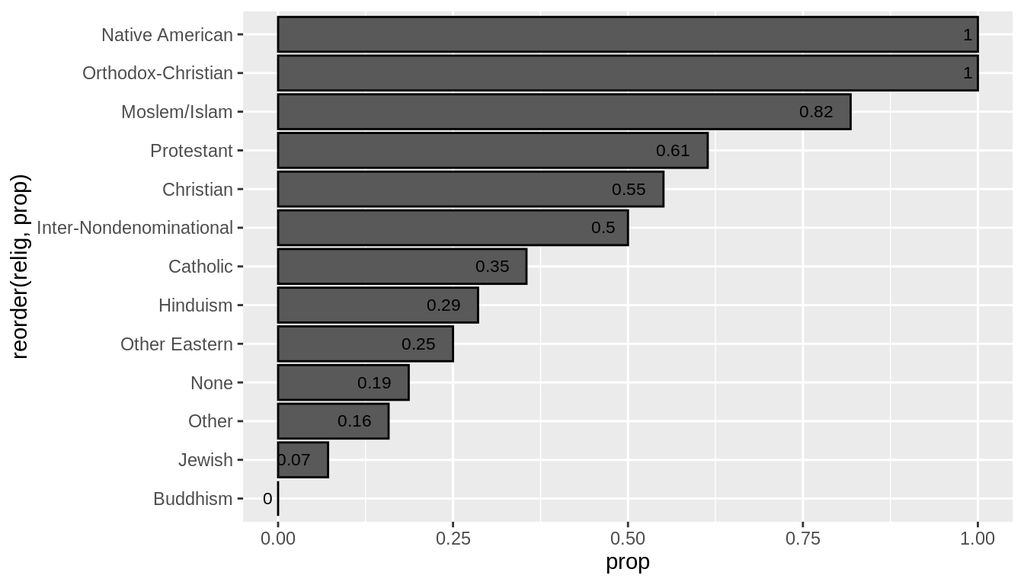

```r
GSSData %>%
  group_by(relig) %>%
  summarise(prop = mean(homosex=='Always Wrong')) %>%
  ggplot(aes(x = reorder(relig, prop), y=prop)) +
  geom_bar(colour="black", stat="identity")+
  coord_flip()+
  geom_text(aes(label = round(prop,2)), size = 3, hjust = 1.5)
```

Analyzing the proportion of each religion, we notice that Native Americans and Orthodox-Christian are the ones who most strongly disagree with homosexual relationships, we also see that the proportion of Protestants is almost double of Catholics. Now we need to know if this is a statistical difference. * * *

## Part 4: Inference

#Hypothesis Test

Are the proportions for Protestants and Catholics who strongly disagree with homosexual relationships significantly different? To answer that, we built the following hypothesis test:

H0: p_Protestant = p_Catholic HA: p_Protestant != p_Catholic

In other words, the null hypothesis says that is no difference in both proportions and de alternative hypothesis says that are.

#Build dataframe

We classify everything that is not “Always Wrong’ as”Other’, so the answer to the opinion of people have a binary value.

```r
GSSData$homosex <- ifelse(GSSData$homosex!='Always Wrong','Other','Always Wrong')
GSSDataSub <- subset(GSSData, relig == 'Protestant' | relig =='Catholic')
```

After, we created a dataframe only with the two columns:

```r
Religion <- factor(GSSDataSub$relig)
Desagree <- factor(GSSDataSub$homosex)

dataframe <- data.frame(Religion = Religion,
                 Desagree = Desagree)
str(dataframe)
```

```
## 'data.frame':    881 obs. of  2 variables:
##  $ Religion: Factor w/ 2 levels "Protestant","Catholic": 2 2 1 1 2 1 1 2 2 2 ...
##  $ Desagree: Factor w/ 2 levels "Always Wrong",..: 2 1 2 2 2 1 2 2 2 1 ...
```

```r
#Variables
n1 <- summarise(dataframe, n1= sum(Religion == 'Protestant'))
n2 <- summarise(dataframe, n2= sum(Religion == 'Catholic'))

s1 <- summarise(dataframe, s1 =sum(Religion == 'Protestant' & Desagree == 'Always Wrong'))
s2 <- summarise(dataframe, s2 =sum(Religion == 'Catholic' & Desagree == 'Always Wrong'))

ppool     <- (s1 + s2) / (n1 + n2)  # Pooled Proportion
cppool    <- 1-ppool               # Complement of Pooled Proportion
```

#Test the conditions

We need to test the conditions to assume that the distribution is nearly normal:

```r
# 1) Independence
# 1.1) Within Groups:
# 1.1.1) Sample observations must be independent within each group - ok
# 1.1.2) If sampling without replacement,  n < 10% of the population - ok

#1.2) Between Groups:
#1.2.1)The two groups must be independent of each other (non-paired) -pk

#  2) Sample Size/Skewness: Each sample should meet the success-failure condition:

#Test Success Conditions:
tsc1 <- n1*ppool   > 10
tfc1 <- n1*cppool  > 10
tsc2 <- n2*ppool   > 10
tfc2 <- n2*cppool  > 10

c(tsc1,tfc1,tsc2,tfc2)
```

```
## [1] TRUE TRUE TRUE TRUE
```

Conditions are met, so we can continue.

# P-Value

```r
inference(y = Desagree, x=Religion, data = dataframe,
          statistic = "proportion",
          type = "ht",
          null=0,
          alternative = "twosided",
          method = "theoretical",
          success = "Always Wrong")
```

```
## Response variable: categorical (2 levels, success: Always Wrong)
## Explanatory variable: categorical (2 levels)
## n_Protestant = 588, p_hat_Protestant = 0.6139
## n_Catholic = 293, p_hat_Catholic = 0.3549
## H0: p_Protestant =  p_Catholic
## HA: p_Protestant != p_Catholic
## z = 7.2549
## p_value = < 0.0001
```

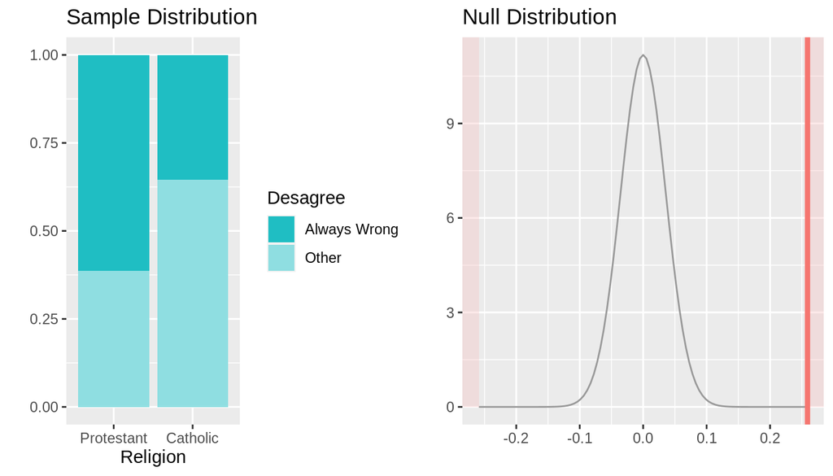

We can also verify the confidence intervals, for a double check:

#Confidence Level

```r
#Variables
p1 <- summarise(dataframe, p1 =sum(Religion == 'Protestant' & Desagree == 'Always Wrong')/sum(Religion == 'Protestant'))
p2 <- summarise(dataframe, p2 =sum(Religion == 'Catholic' & Desagree == 'Always Wrong')/sum(Religion == 'Catholic'))

cpe1 <- 1-p1 # complement of point estimate 1
cpe2 <- 1-p2 # complement of point estimate 2
```

Check conditions:

```r
# 1) Independence
# 1.1) Within Groups:
# 1.1.1) Sample observations must be independent within each group - ok
# 1.1.2) If sampling without replacement,  n < 10% of the population - ok

#1.2) Between Groups:
#1.2.1)The two groups must be independent of each other (non-paired) -pk

#  2) Sample Size/Skewness: Each sample should meet the success-failure condition:

#Test Success Conditions:
tsc1 <- n1*p1   > 10
tfc1 <- n1*cpe1  > 10
tsc2 <- n2*p2   > 10
tfc2 <- n2*cpe2  > 10

c(tsc1,tfc1,tsc2,tfc2)
```

```
## [1] TRUE TRUE TRUE TRUE
```

Conditions are met, so we can continue.

```r
Protestants <- subset(dataframe, Religion== "Protestant")
Catholics <- subset(dataframe, Religion== "Catholic")
```

```r
inference(y = Desagree, data = Protestants, statistic = "proportion", type = "ci", method = "theoretical",   success = "Always Wrong")
```

```
## Single categorical variable, success: Always Wrong
## n = 588, p-hat = 0.6139
## 95% CI: (0.5746 , 0.6533)
```

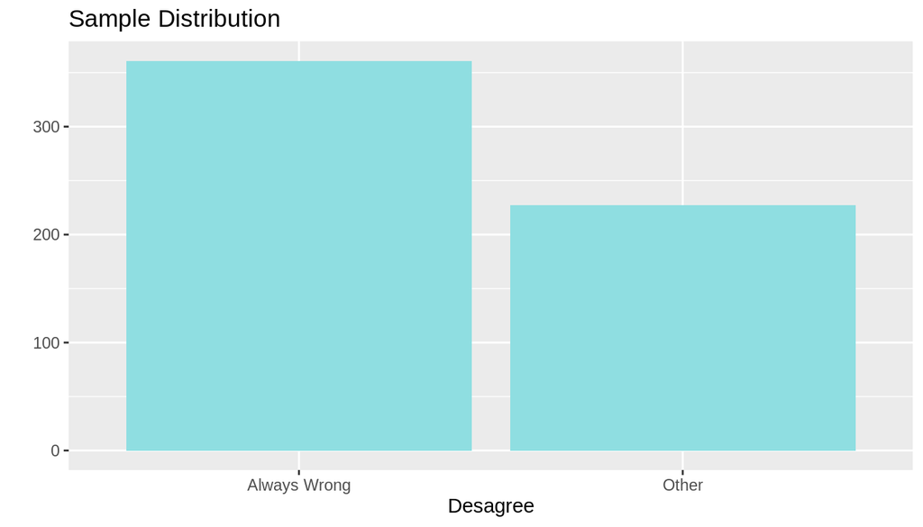

```r
inference(y = Desagree, data = Catholics, statistic = "proportion", type = "ci", method = "theoretical",   success = "Always Wrong")
```

```
## Single categorical variable, success: Always Wrong
## n = 293, p-hat = 0.3549
## 95% CI: (0.3002 , 0.4097)
```

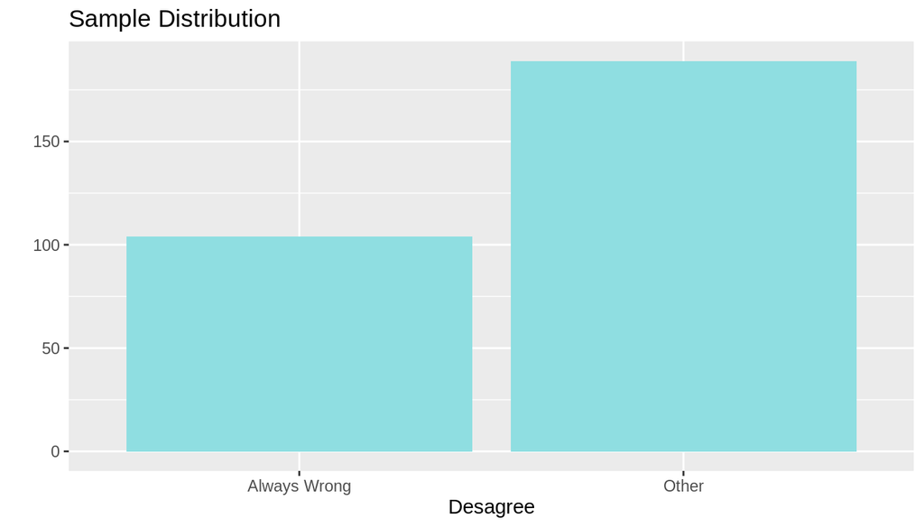

We can see the range of the proportion of Protestants (0.5746 , 0.6533) does not contain the range of proportion of Catholics (0.3002 , 0.4097) and vice versa, so there is a significant difference between the two religions when it comes to being strongly opposed to the homosexual relationship, confirming the result obtained previously by the method of hypothesis testing.